# The Iris Dataset EDA

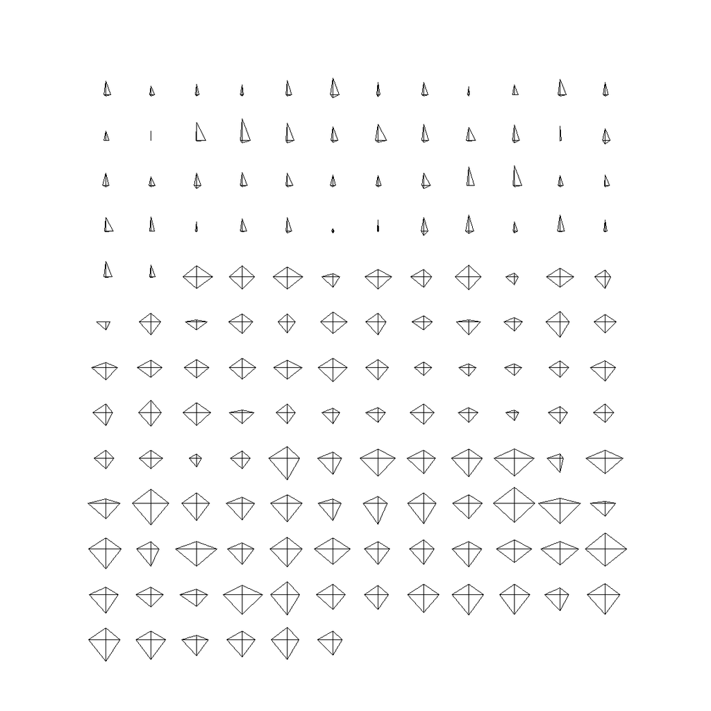

```r
stars(df)
```

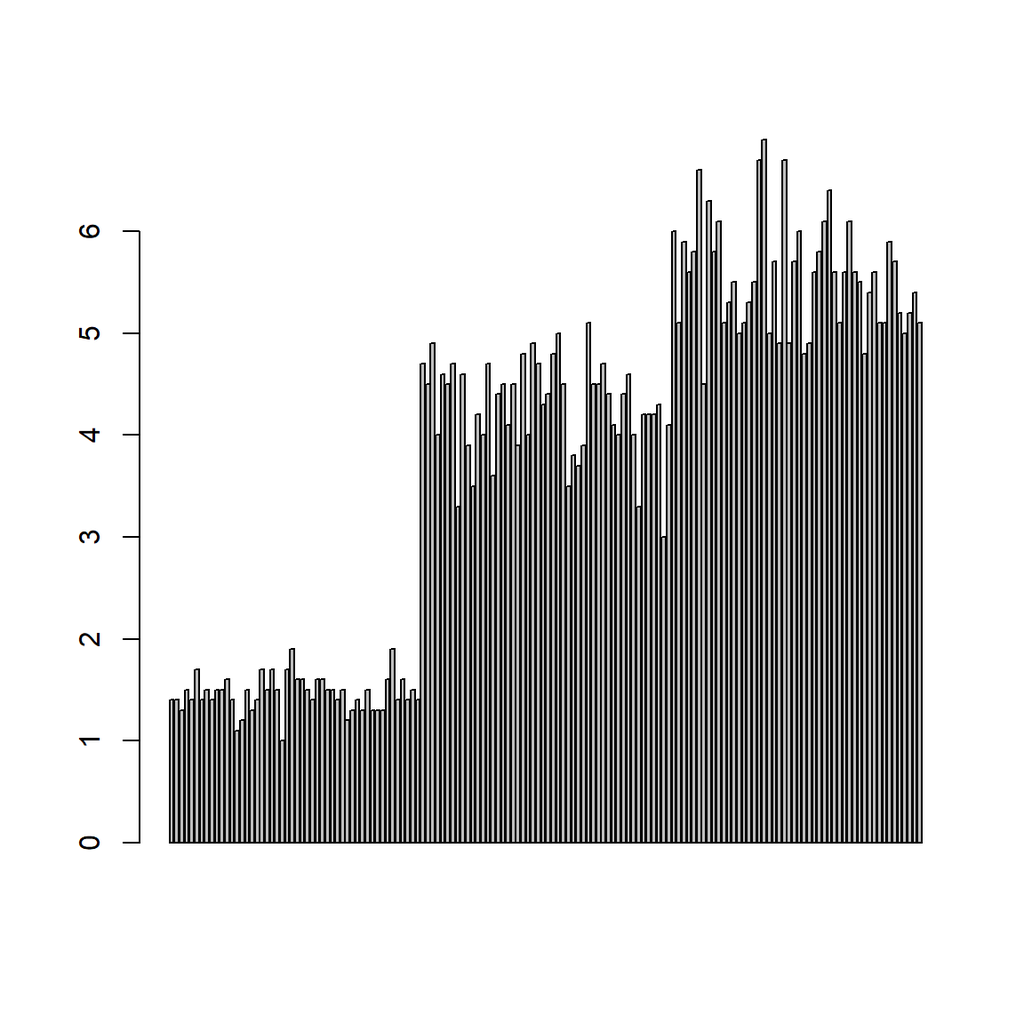

```r
PL <- df$Petal.Length
barplot(PL)
```

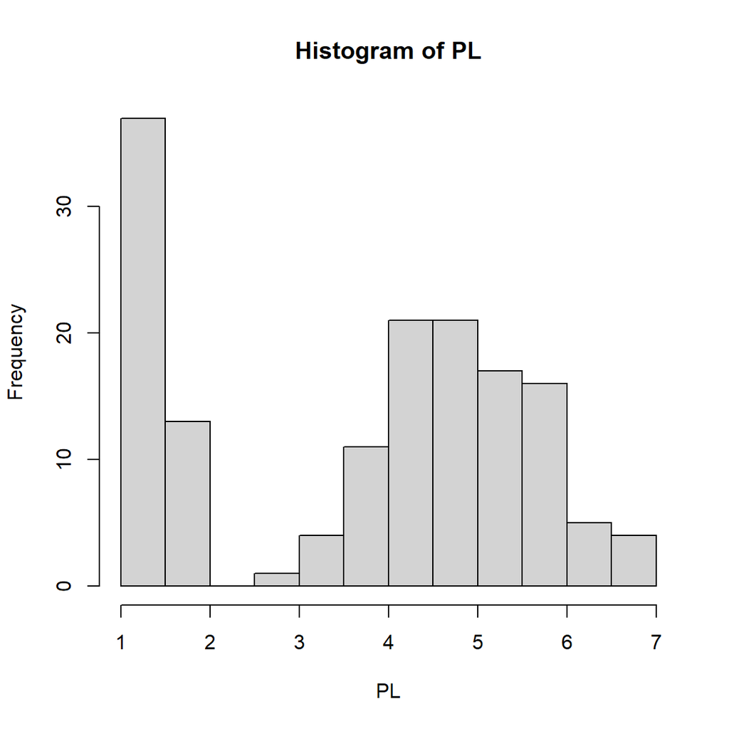

```r
hist(PL)
```

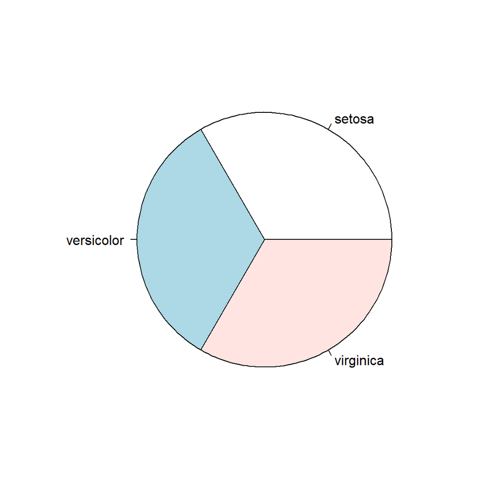

```r
SP <- iris$Species
pie(table(SP))
```

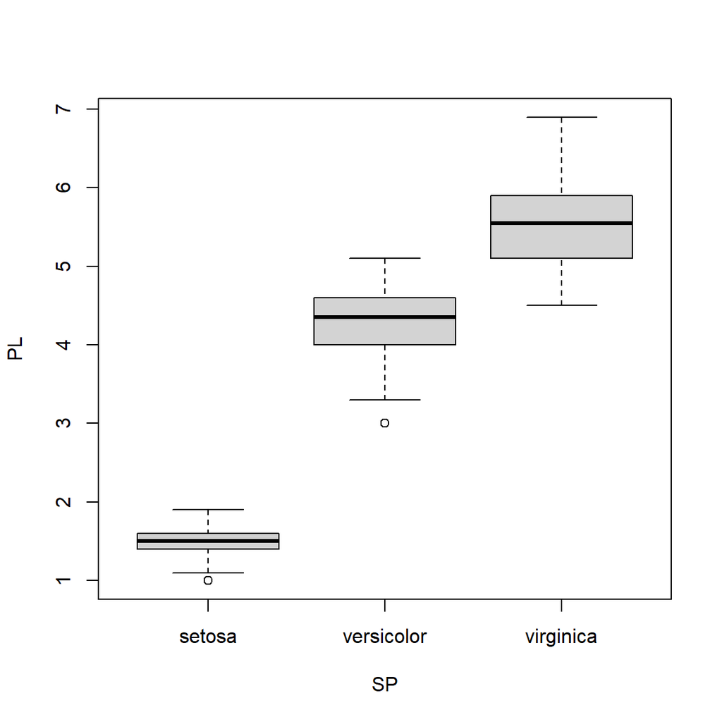

```r
boxplot(PL ~ SP)
```

```r
summary(aov(PL ~ SP))
```

```
##              Df Sum Sq Mean Sq F value Pr(>F)
## SP            2  437.1  218.55    1180 <2e-16 ***
## Residuals   147   27.2    0.19
## ---
## Signif. codes:  0 '***' 0.001 '**' 0.01 '*' 0.05 '.' 0.1 ' ' 1
```

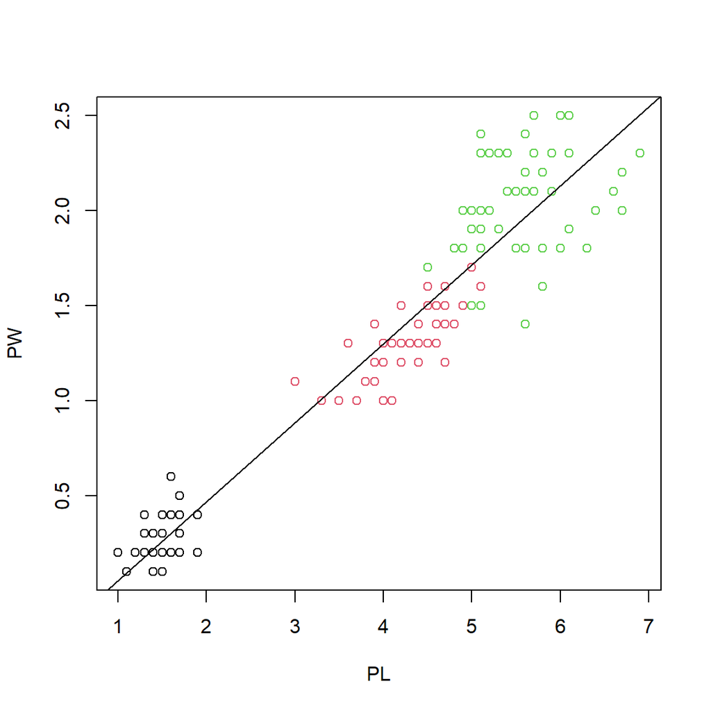

```r
PW <- df$Petal.Width
plot(PL, PW, col = SP)
abline(lm(PW ~ PL))
```

```r
summary(PL)
```

```
##    Min. 1st Qu.  Median    Mean 3rd Qu.    Max.
##   1.000   1.600   4.350   3.758   5.100   6.900
```

# This produces a lot of useful information about the distribution of petal length:

The minimum is 1.000, and the maximum is 6.900.

Average petal length is 3.758.

The mid-point, or median, is 4.350, as about half of the numbers are smaller than 4.350. Why the median is different from the mean? What happens if there is a typo and one number is entered 340cm instead of 3.40cm?

The 3rd quartile, or 75th percentile, is 5.100, as 75% of the flowers have petals shorter than 5.100. If a student’s GPA ranks 5th in a class of 25, he/she is at 80th percentile. The minimum is the 0th percentile and the maximum is the 100th percentile.

The 1st quartile, or 25th percentile, is 1.600. Only 25% of the flowers have petals shorter than 1.600. These summary statistics are graphically represented as a boxplot. Boxplots are more useful when multiple sets of numbers are compared.

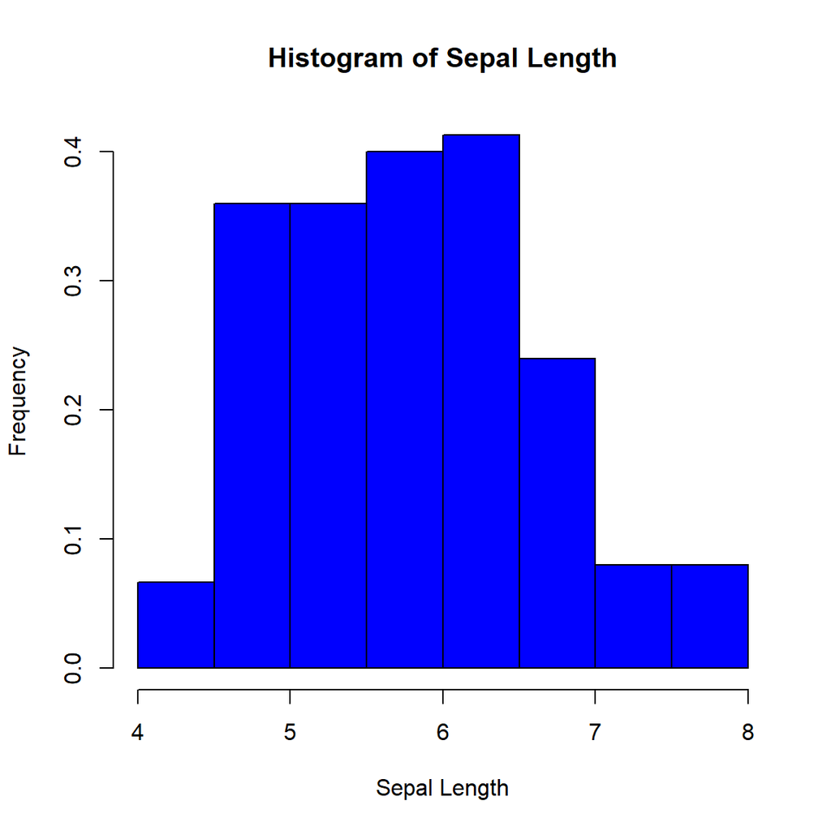

```r
# View(iris) # show as a spreadsheet
SL <- df$Sepal.Length
hist(SL, main="Histogram of Sepal Length", xlab="Sepal Length",
     ylab='Frequency', xlim=c(4,8), col="blue", freq=FALSE)
```

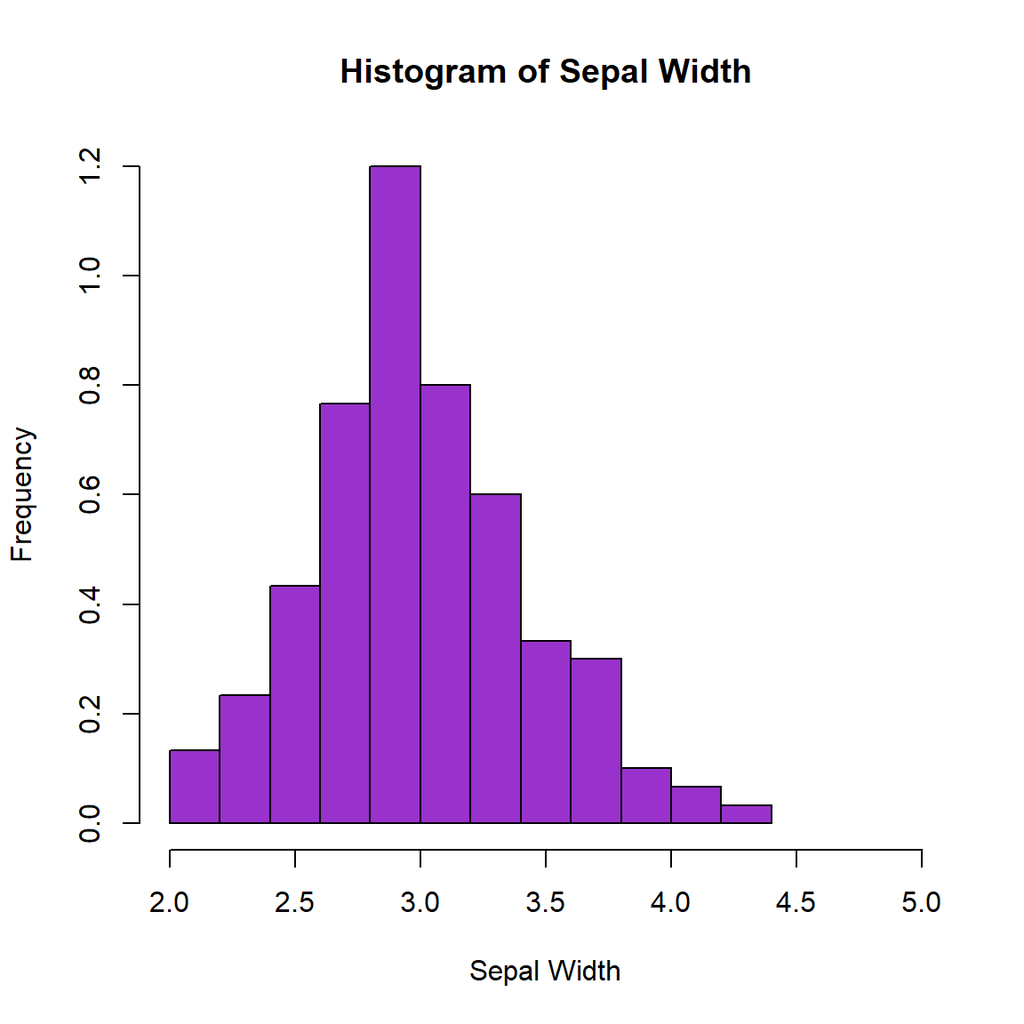

```r
SW <- df$Sepal.Width

hist(SW, main="Histogram of Sepal Width", xlab="Sepal Width",
     ylab='Frequency', xlim=c(2,5), col="darkorchid", freq=FALSE)
```

# Box Plot shows 5 statistically significant numbers- the minimum, the 25th percentile, the median, the 75th percentile and the maximum. It is thus useful for visualizing the spread of the data is and deriving inferences accordingly.

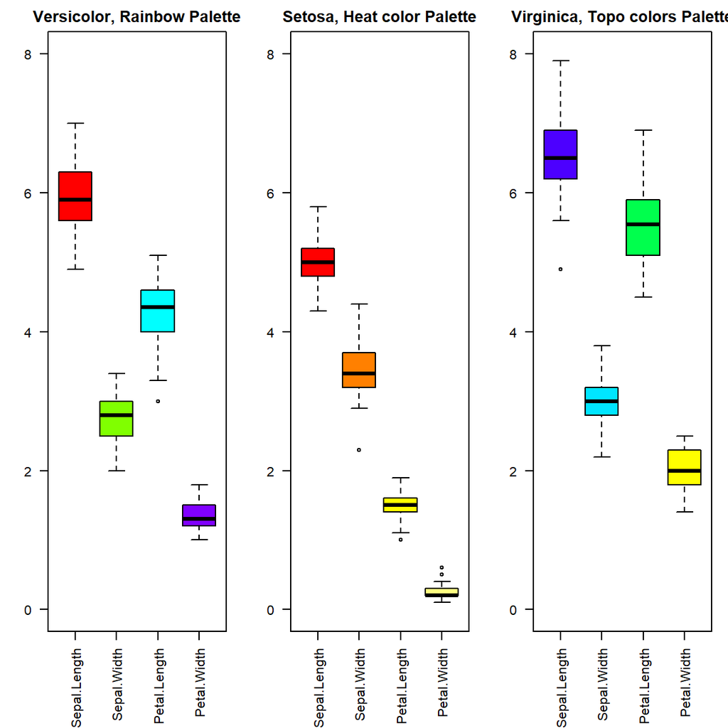

```r
irisVer <- subset(iris, Species == "versicolor")
irisSet <- subset(iris, Species == "setosa")
irisVir <- subset(iris, Species == "virginica")
par(mfrow=c(1,3),mar=c(6,3,2,1))
boxplot(irisVer[,1:4], main="Versicolor, Rainbow Palette",ylim = c(0,8),las=2, col=rainbow(4))
boxplot(irisSet[,1:4], main="Setosa, Heat color Palette",ylim = c(0,8),las=2, col=heat.colors(4))
boxplot(irisVir[,1:4], main="Virginica, Topo colors Palette",ylim = c(0,8),las=2, col=topo.colors(4))
```

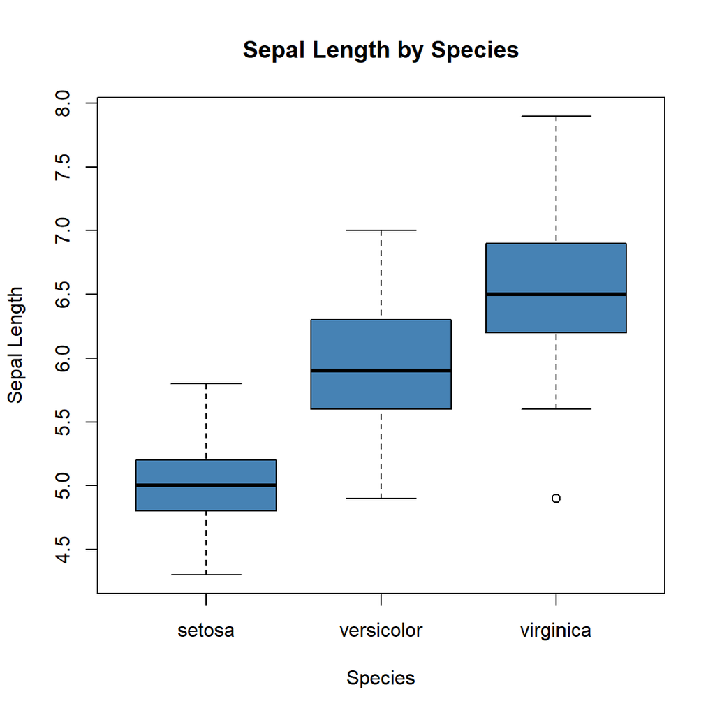

```r
# create boxplot of sepal width vs. sepal length
boxplot(Sepal.Length~Species,
        data=iris,
        main='Sepal Length by Species',
        xlab='Species',
        ylab='Sepal Length',
        col='steelblue',
        border='black')
```

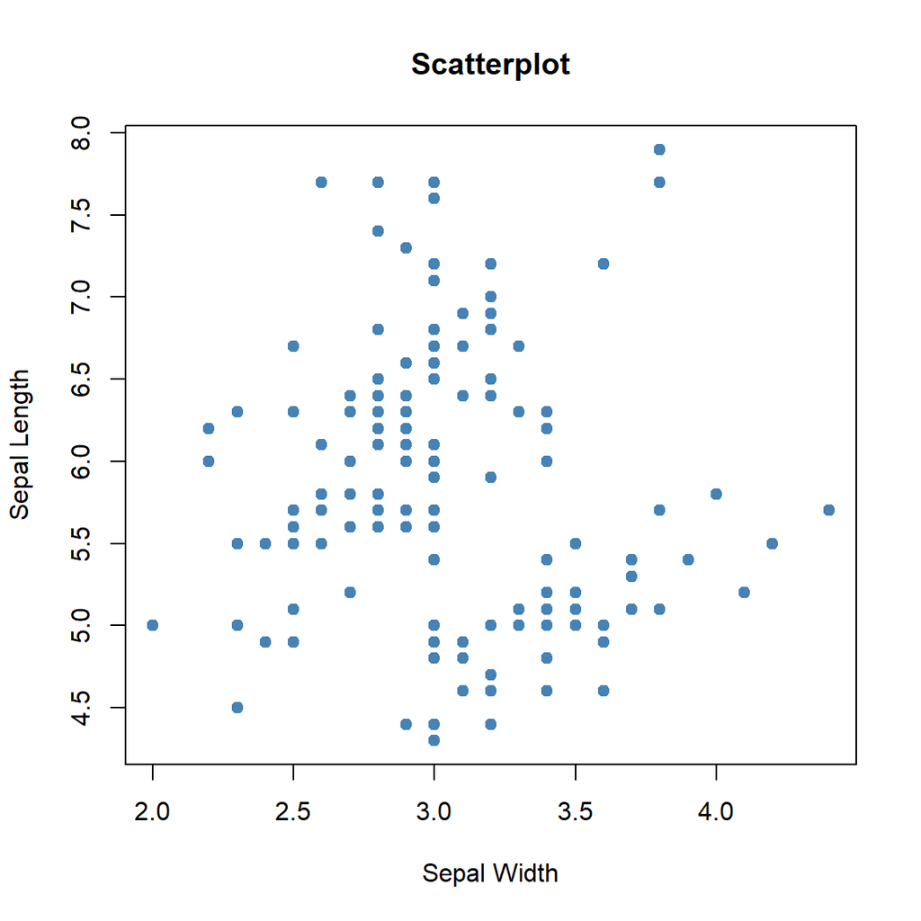

```r
# create scatterplot of sepal width vs. sepal length
plot(iris$Sepal.Width, iris$Sepal.Length,
     col='steelblue',
     main='Scatterplot',
     xlab='Sepal Width',
     ylab='Sepal Length',
     pch=19)
```

# Scatterplot Matrices

When we have two or more variables and we want to correlate between one variable and others so we use a scatterplot matrix.

pairs() function is used to create matrices of scatterplots.

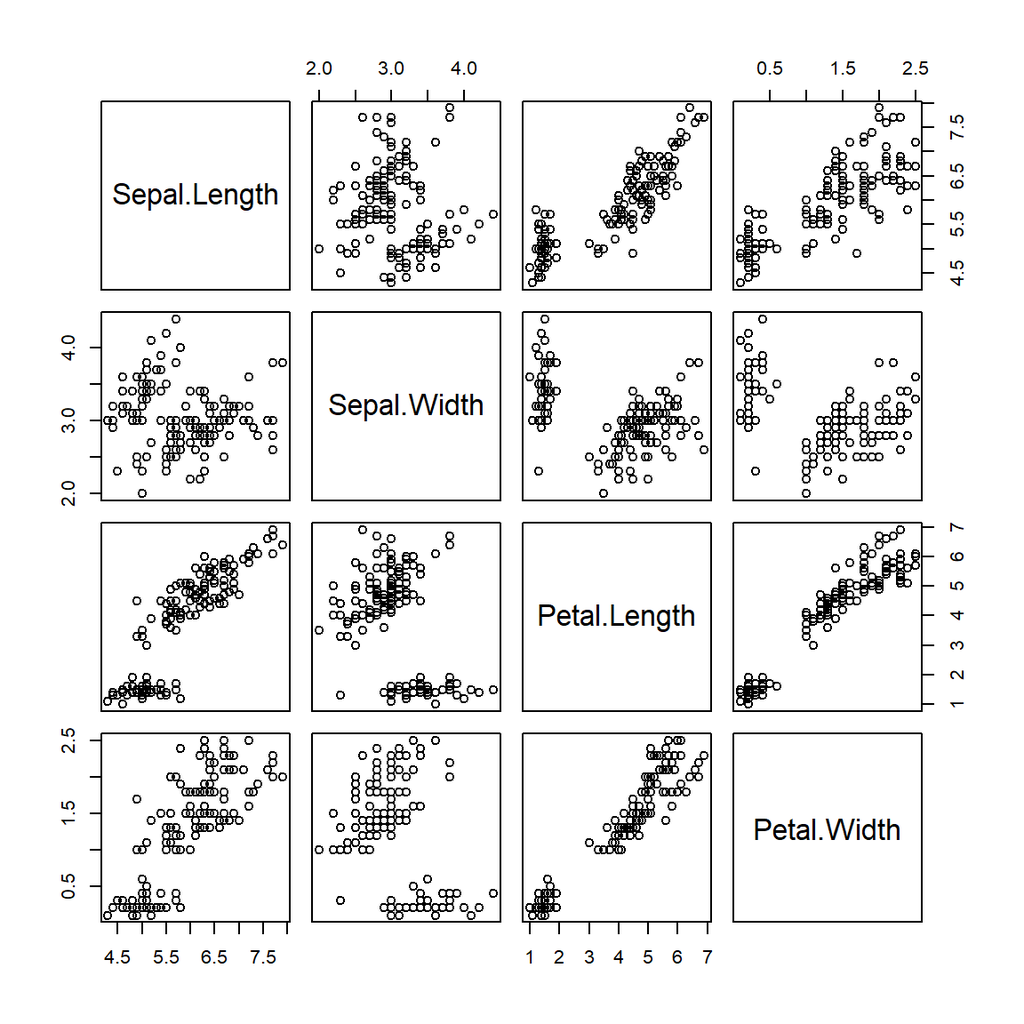

```r
x <- iris[, 1:4]
pairs(x)
```